# Building a machine learning model to predict user churn

```python
# Import packages

# For data manipulation

import pandas as pd
import numpy as np

# For data visualization

import matplotlib.pyplot as plt
import seaborn as sns

# For hypothesis testing

from scipy import stats

# For logistic regression & confusion matrix

from sklearn.preprocessing import StandardScaler, OneHotEncoder
from sklearn.model_selection import train_test_split
from sklearn.metrics import classification_report, accuracy_score, precision_score, \
recall_score, f1_score, confusion_matrix, ConfusionMatrixDisplay
from sklearn.linear_model import LogisticRegression

# This lets see all of the columns, preventing Juptyer from redacting them

pd.set_option('display.max_columns', None)

# For data modeling
from sklearn.model_selection import GridSearchCV, train_test_split
from sklearn.metrics import roc_auc_score, roc_curve, auc
from sklearn.metrics import accuracy_score, precision_score, recall_score,\
f1_score, confusion_matrix, ConfusionMatrixDisplay, RocCurveDisplay, PrecisionRecallDisplay

from sklearn.ensemble import RandomForestClassifier
import xgboost as xgb
from xgboost import XGBClassifier

# This is the function that helps plot feature importance
from xgboost import plot_importance

# This module lets save the models once they are fitted
import pickle

# Ignore warnings
import warnings
warnings.filterwarnings("ignore")
```

```python
# Load dataset into dataframe

df = pd.read_csv("C:\data_science\data\waze_project_dataset.csv")
```

### 1. Data Exploration

```python
df.describe()
```

|  | ID | sessions | drives | total_sessions | n_days_after_onboarding | total_navigations_fav1 | total_navigations_fav2 | driven_km_drives | duration_minutes_drives | activity_days | driving_days |
| --- | --- | --- | --- | --- | --- | --- | --- | --- | --- | --- | --- |
| count | 14999.000000 | 14999.000000 | 14999.000000 | 14999.000000 | 14999.000000 | 14999.000000 | 14999.000000 | 14999.000000 | 14999.000000 | 14999.000000 | 14999.000000 |
| mean | 7499.000000 | 80.633776 | 67.281152 | 189.964447 | 1749.837789 | 121.605974 | 29.672512 | 4039.340921 | 1860.976012 | 15.537102 | 12.179879 |
| std | 4329.982679 | 80.699065 | 65.913872 | 136.405128 | 1008.513876 | 148.121544 | 45.394651 | 2502.149334 | 1446.702288 | 9.004655 | 7.824036 |
| min | 0.000000 | 0.000000 | 0.000000 | 0.220211 | 4.000000 | 0.000000 | 0.000000 | 60.441250 | 18.282082 | 0.000000 | 0.000000 |
| 25% | 3749.500000 | 23.000000 | 20.000000 | 90.661156 | 878.000000 | 9.000000 | 0.000000 | 2212.600607 | 835.996260 | 8.000000 | 5.000000 |
| 50% | 7499.000000 | 56.000000 | 48.000000 | 159.568115 | 1741.000000 | 71.000000 | 9.000000 | 3493.858085 | 1478.249859 | 16.000000 | 12.000000 |
| 75% | 11248.500000 | 112.000000 | 93.000000 | 254.192341 | 2623.500000 | 178.000000 | 43.000000 | 5289.861262 | 2464.362632 | 23.000000 | 19.000000 |
| max | 14998.000000 | 743.000000 | 596.000000 | 1216.154633 | 3500.000000 | 1236.000000 | 415.000000 | 21183.401890 | 15851.727160 | 31.000000 | 30.000000 |

```python
df.head(10)
```

|  | ID | label | sessions | drives | total_sessions | n_days_after_onboarding | total_navigations_fav1 | total_navigations_fav2 | driven_km_drives | duration_minutes_drives | activity_days | driving_days | device |
| --- | --- | --- | --- | --- | --- | --- | --- | --- | --- | --- | --- | --- | --- |
| 0 | 0 | retained | 283 | 226 | 296.748273 | 2276 | 208 | 0 | 2628.845068 | 1985.775061 | 28 | 19 | Android |
| 1 | 1 | retained | 133 | 107 | 326.896596 | 1225 | 19 | 64 | 13715.920550 | 3160.472914 | 13 | 11 | iPhone |
| 2 | 2 | retained | 114 | 95 | 135.522926 | 2651 | 0 | 0 | 3059.148818 | 1610.735904 | 14 | 8 | Android |
| 3 | 3 | retained | 49 | 40 | 67.589221 | 15 | 322 | 7 | 913.591123 | 587.196542 | 7 | 3 | iPhone |
| 4 | 4 | retained | 84 | 68 | 168.247020 | 1562 | 166 | 5 | 3950.202008 | 1219.555924 | 27 | 18 | Android |
| 5 | 5 | retained | 113 | 103 | 279.544437 | 2637 | 0 | 0 | 901.238699 | 439.101397 | 15 | 11 | iPhone |
| 6 | 6 | retained | 3 | 2 | 236.725314 | 360 | 185 | 18 | 5249.172828 | 726.577205 | 28 | 23 | iPhone |
| 7 | 7 | retained | 39 | 35 | 176.072845 | 2999 | 0 | 0 | 7892.052468 | 2466.981741 | 22 | 20 | iPhone |
| 8 | 8 | retained | 57 | 46 | 183.532018 | 424 | 0 | 26 | 2651.709764 | 1594.342984 | 25 | 20 | Android |
| 9 | 9 | churned | 84 | 68 | 244.802115 | 2997 | 72 | 0 | 6043.460295 | 2341.838528 | 7 | 3 | iPhone |

```python
df.info()
```

```
<class 'pandas.core.frame.DataFrame'>
RangeIndex: 14999 entries, 0 to 14998
Data columns (total 13 columns):
 #   Column                   Non-Null Count  Dtype
---  ------                   --------------  -----
 0   ID                       14999 non-null  int64
 1   label                    14299 non-null  object
 2   sessions                 14999 non-null  int64
 3   drives                   14999 non-null  int64
 4   total_sessions           14999 non-null  float64
 5   n_days_after_onboarding  14999 non-null  int64
 6   total_navigations_fav1   14999 non-null  int64
 7   total_navigations_fav2   14999 non-null  int64
 8   driven_km_drives         14999 non-null  float64
 9   duration_minutes_drives  14999 non-null  float64
 10  activity_days            14999 non-null  int64
 11  driving_days             14999 non-null  int64
 12  device                   14999 non-null  object
dtypes: float64(3), int64(8), object(2)
memory usage: 1.5+ MB
```

```python
df.size
```

```
194987
```

#### Comments

- There are 0s (i.e., variables with missing values) in 'total_navigations_fav1' and 'total_navigations_fav2' columns.
- Data types: float64(3), int64(8), object(2). There are 13 columns and 14999 rows.
- There are missing values in a column 'label' (700 missing values).

```python
# Isolate rows with null values

null_mask = df.isnull().any(axis = 1)
null_rows = df[null_mask]

print(null_rows)

# Display summary stats of rows with null values

null_rows.describe()
```

```
          ID label  sessions  drives  total_sessions  n_days_after_onboarding  \
77        77   NaN        63      50      133.104155                      783
80        80   NaN       116      93      436.060183                     1584
98        98   NaN        78      64      583.492789                     3414
111      111   NaN       106     102      113.379056                     2228
142      142   NaN        32      26      222.129310                      208
...      ...   ...       ...     ...             ...                      ...
14941  14941   NaN       191     160      485.328204                     1287
14943  14943   NaN        48      38       96.797017                      555
14945  14945   NaN        34      29      134.416604                     1643
14972  14972   NaN       220     181      256.212166                     1718
14993  14993   NaN        67      57       97.570074                     1131

       total_navigations_fav1  total_navigations_fav2  driven_km_drives  \
77                        201                       0       2649.015822
```

[output cut: 25 more lines]

|  | ID | sessions | drives | total_sessions | n_days_after_onboarding | total_navigations_fav1 | total_navigations_fav2 | driven_km_drives | duration_minutes_drives | activity_days | driving_days |
| --- | --- | --- | --- | --- | --- | --- | --- | --- | --- | --- | --- |
| count | 700.000000 | 700.000000 | 700.000000 | 700.000000 | 700.000000 | 700.000000 | 700.000000 | 700.000000 | 700.000000 | 700.000000 | 700.000000 |
| mean | 7405.584286 | 80.837143 | 67.798571 | 198.483348 | 1709.295714 | 118.717143 | 30.371429 | 3935.967029 | 1795.123358 | 15.382857 | 12.125714 |
| std | 4306.900234 | 79.987440 | 65.271926 | 140.561715 | 1005.306562 | 156.308140 | 46.306984 | 2443.107121 | 1419.242246 | 8.772714 | 7.626373 |
| min | 77.000000 | 0.000000 | 0.000000 | 5.582648 | 16.000000 | 0.000000 | 0.000000 | 290.119811 | 66.588493 | 0.000000 | 0.000000 |
| 25% | 3744.500000 | 23.000000 | 20.000000 | 94.056340 | 869.000000 | 4.000000 | 0.000000 | 2119.344818 | 779.009271 | 8.000000 | 6.000000 |
| 50% | 7443.000000 | 56.000000 | 47.500000 | 177.255925 | 1650.500000 | 62.500000 | 10.000000 | 3421.156721 | 1414.966279 | 15.000000 | 12.000000 |
| 75% | 11007.000000 | 112.250000 | 94.000000 | 266.058022 | 2508.750000 | 169.250000 | 43.000000 | 5166.097373 | 2443.955404 | 23.000000 | 18.000000 |
| max | 14993.000000 | 556.000000 | 445.000000 | 1076.879741 | 3498.000000 | 1096.000000 | 352.000000 | 15135.391280 | 9746.253023 | 31.000000 | 30.000000 |

```python
# Isolate rows without null values

not_null_mask = df.notnull().all(axis = 1)
not_null_rows = df[not_null_mask]

print(not_null_rows)

# Display summary stats of rows without null values

not_null_rows.describe()
```

```
          ID     label  sessions  drives  total_sessions  \
0          0  retained       283     226      296.748273
1          1  retained       133     107      326.896596
2          2  retained       114      95      135.522926
3          3  retained        49      40       67.589221
4          4  retained        84      68      168.247020
...      ...       ...       ...     ...             ...
14994  14994  retained        60      55      207.875622
14995  14995  retained        42      35      187.670313
14996  14996  retained       273     219      422.017241
14997  14997   churned       149     120      180.524184
14998  14998  retained        73      58      353.419797

       n_days_after_onboarding  total_navigations_fav1  \
0                         2276                     208
```

[output cut: 38 more lines]

|  | ID | sessions | drives | total_sessions | n_days_after_onboarding | total_navigations_fav1 | total_navigations_fav2 | driven_km_drives | duration_minutes_drives | activity_days | driving_days |
| --- | --- | --- | --- | --- | --- | --- | --- | --- | --- | --- | --- |
| count | 14299.000000 | 14299.000000 | 14299.000000 | 14299.000000 | 14299.000000 | 14299.000000 | 14299.000000 | 14299.000000 | 14299.000000 | 14299.000000 | 14299.000000 |
| mean | 7503.573117 | 80.623820 | 67.255822 | 189.547409 | 1751.822505 | 121.747395 | 29.638296 | 4044.401535 | 1864.199794 | 15.544653 | 12.182530 |
| std | 4331.207621 | 80.736502 | 65.947295 | 136.189764 | 1008.663834 | 147.713428 | 45.350890 | 2504.977970 | 1448.005047 | 9.016088 | 7.833835 |
| min | 0.000000 | 0.000000 | 0.000000 | 0.220211 | 4.000000 | 0.000000 | 0.000000 | 60.441250 | 18.282082 | 0.000000 | 0.000000 |
| 25% | 3749.500000 | 23.000000 | 20.000000 | 90.457733 | 878.500000 | 10.000000 | 0.000000 | 2217.319909 | 840.181344 | 8.000000 | 5.000000 |
| 50% | 7504.000000 | 56.000000 | 48.000000 | 158.718571 | 1749.000000 | 71.000000 | 9.000000 | 3496.545617 | 1479.394387 | 16.000000 | 12.000000 |
| 75% | 11257.500000 | 111.000000 | 93.000000 | 253.540450 | 2627.500000 | 178.000000 | 43.000000 | 5299.972162 | 2466.928876 | 23.000000 | 19.000000 |
| max | 14998.000000 | 743.000000 | 596.000000 | 1216.154633 | 3500.000000 | 1236.000000 | 415.000000 | 21183.401890 | 15851.727160 | 31.000000 | 30.000000 |

```python
# Get count of null values by device

null_rows['device'].value_counts()
```

```
device
iPhone     447
Android    253
Name: count, dtype: int64
```

```python
# Calculate % of iPhone nulls and Android nulls

null_rows.device.value_counts(normalize = True).mul(100).round(1).astype(str) + '%'
```

```
device
iPhone     63.9%
Android    36.1%
Name: proportion, dtype: object
```

```python
# Calculate % of iPhone users and Android users in full dataset

df.device.value_counts(normalize = True).mul(100).round(1).astype(str) + '%'
```

```
device
iPhone     64.5%
Android    35.5%
Name: proportion, dtype: object
```

```python
# Calculate counts of churned vs. retained

percentages = df.label.value_counts(normalize = True).mul(100).round(1).astype(str) + '%'

counts = df.label.value_counts()

# Concatenate results into one DataFrame

pd.concat([counts, percentages], axis = 1, keys = ['counts', 'percentages'])
```

| label | counts | percentages |
| --- | --- | --- |
| retained | 11763 | 82.3% |
| churned | 2536 | 17.7% |

```python
# Calculate median values of all columns for churned and retained users

df.groupby('label').median(numeric_only = True)
```

| label | ID | sessions | drives | total_sessions | n_days_after_onboarding | total_navigations_fav1 | total_navigations_fav2 | driven_km_drives | duration_minutes_drives | activity_days | driving_days |
| --- | --- | --- | --- | --- | --- | --- | --- | --- | --- | --- | --- |
| churned | 7477.5 | 59.0 | 50.0 | 164.339042 | 1321.0 | 84.5 | 11.0 | 3652.655666 | 1607.183785 | 8.0 | 6.0 |
| retained | 7509.0 | 56.0 | 47.0 | 157.586756 | 1843.0 | 68.0 | 9.0 | 3464.684614 | 1458.046141 | 17.0 | 14.0 |

#### Comments

It seems that churned users had more drives in fewer days, and their trips were farther and longer in duration.

```python
# Add a column to df called 'km_per_drive'

df[['km_per_drive']] = df[['driven_km_drives']].div(df['drives'], axis = 0)

# Group by 'label', calculate the median, and isolate for km per drive

df.groupby("label").median(numeric_only = True)["km_per_drive"]
```

```
label
churned     74.109416
retained    75.014702
Name: km_per_drive, dtype: float64
```

```python
# Add a column to df called 'km_per_driving_day'

df[['km_per_driving_day']] = df[['driven_km_drives']].div(df['driving_days'], axis = 0)

# Group by 'label', calculate the median, and isolate for km per driving day

df.groupby('label').median(numeric_only = True)['km_per_driving_day']
```

```
label
churned     697.541999
retained    289.549333
Name: km_per_driving_day, dtype: float64
```

```python
# Add a column to df called 'drives_per_driving_day'

df[['drives_per_driving_day']] = df[['drives']].div(df['driving_days'], axis = 0)

# Group by 'label', calculate the median, and isolate for drives per driving day

df.groupby('label').median(numeric_only = True)['drives_per_driving_day']
```

```
label
churned     10.0000
retained     4.0625
Name: drives_per_driving_day, dtype: float64
```

#### Comments

The median user who churned drove 698 kilometers each day, while retained users drove 290 kilometers.

The users in this data drove a lot; most likely most of this data does not represent typical drivers. Users might have used this app for work(for example, long-haul truckers). If so, then they might have churned because they have different needs than people who use Waze for usual drives.

```python
# For each label, calculate the number of Android users and iPhone users

df.groupby(['label', 'device']).size()
```

```
label     device
churned   Android     891
          iPhone     1645
retained  Android    4183
          iPhone     7580
dtype: int64
```

```python
# For each label, calculate the percentage of Android users and iPhone users

df.groupby('label')['device'].value_counts(normalize = True)
```

```
label     device
churned   iPhone     0.648659
          Android    0.351341
retained  iPhone     0.644393
          Android    0.355607
Name: proportion, dtype: float64
```

#### Comments

The ratio of iPhone users and Android users is consistent between the churned group and the retained group, and those ratios are both consistent with the ratio found in the overall dataset.

### 2. Data visualisation

#### Analysing the number of occurrence of a user opening the app during the month

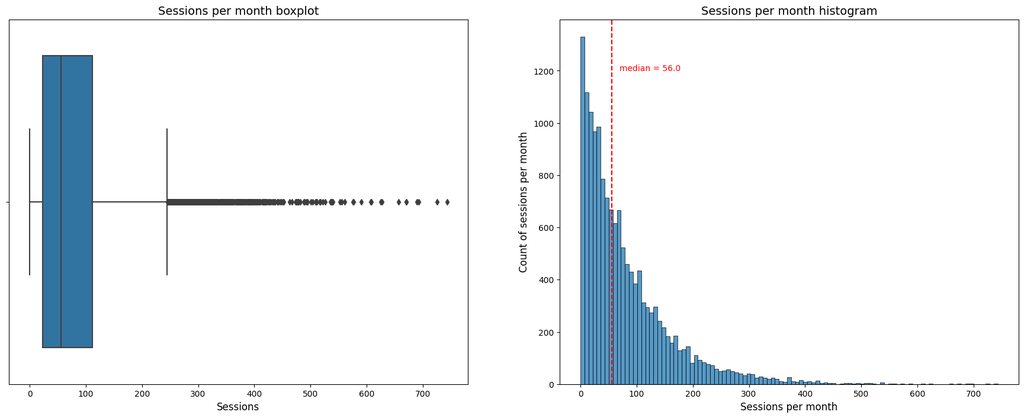

```python
# Set figure and axes

fig, ax = plt.subplots(1, 2, figsize = (22, 8))

# Construct a box plot showing the number of occurrence of a user opening the app during the month

sns.boxplot(data = df, x = 'sessions', ax = ax[0])
ax[0].set_xlabel('Sessions', fontsize = 12)
ax[0].set_title('Sessions per month boxplot', fontsize = 14)

# Construct a histogram showing the number of occurrence of a user opening the app during the month

sns.histplot(data = df, x = 'sessions', stat = 'count', ax = ax[1])

median = df['sessions'].median()
plt.axvline(median, color = 'r', linestyle = '--')
plt.text(70, 1200, 'median = 56.0', color = 'r')

ax[1].set_xlabel('Sessions per month', fontsize = 12)
ax[1].set_ylabel('Count of sessions per month', fontsize = 12)
ax[1].set_title('Sessions per month histogram', fontsize = 14)

plt.show()
```

#### Comments

The 'sessions' variable is a right-skewed distribution with half of the observations having 56 or fewer sessions. However, as indicated by the boxplot, some users have more than 700 sessions.

#### Analysing drives per month

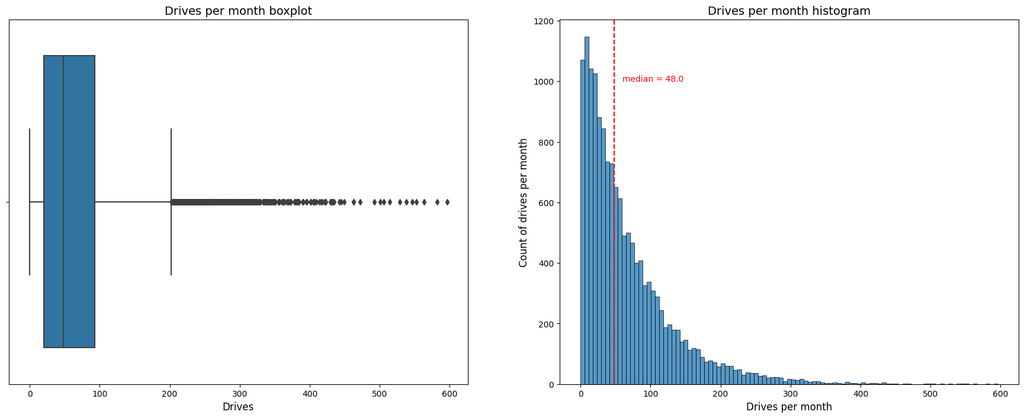

```python
# Set figure and axes

fig, ax = plt.subplots(1, 2, figsize = (22, 8))

# Construct a boxplot showing an occurrence of driving at least 1 km during the month

sns.boxplot(data = df, x = 'drives', ax = ax[0])
ax[0].set_xlabel('Drives', fontsize = 12)
ax[0].set_title('Drives per month boxplot', fontsize = 14)

# Construct a histogram showing an occurrence of driving at least 1 km during the month

sns.histplot(data = df, x = 'drives', stat = 'count', ax = ax[1])

median = df['drives'].median()
plt.axvline(median, color = 'r', linestyle = '--')
plt.text(60, 1000, 'median = 48.0', color = 'r')

ax[1].set_xlabel('Drives per month', fontsize = 12)
ax[1].set_ylabel('Count of drives per month', fontsize = 12)
ax[1].set_title('Drives per month histogram', fontsize = 14)

plt.show()
```

#### Analysing the total number of sessions since a user has onboarded

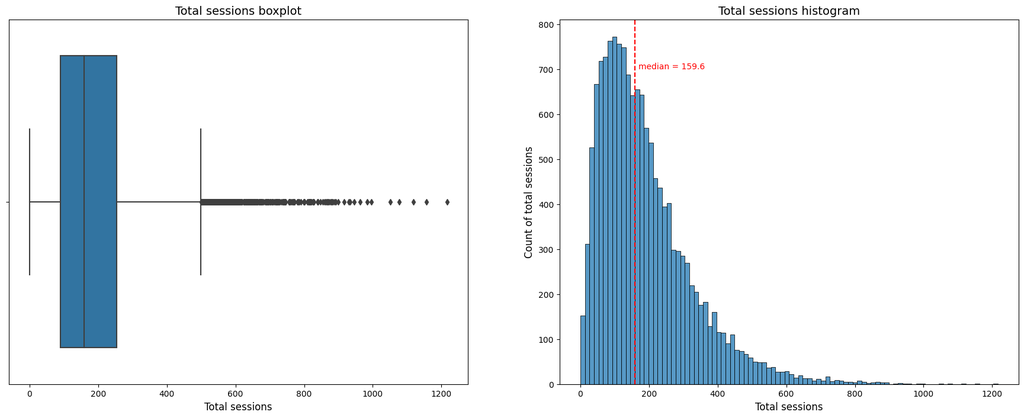

```python
# Set figure and axes

fig, ax = plt.subplots(1, 2, figsize = (22, 8))

# Construct a boxplot showing a model estimate of the total number of sessions since a user has onboarded

sns.boxplot(data = df, x = 'total_sessions', ax = ax[0])
ax[0].set_xlabel('Total sessions', fontsize = 12)
ax[0].set_title('Total sessions boxplot', fontsize = 14)

# Construct a histogram showing a model estimate of the total number of sessions since a user has onboarded

sns.histplot(data = df, x = 'total_sessions', stat = 'count', ax = ax[1])

median = df['total_sessions'].median()
plt.axvline(median, color = 'r', linestyle = '--')
plt.text(170, 700, 'median = 159.6', color = 'r')

ax[1].set_xlabel('Total sessions', fontsize = 12)
ax[1].set_ylabel('Count of total sessions', fontsize = 12)
ax[1].set_title('Total sessions histogram', fontsize = 14)

plt.show()
```

#### Comments

It seems that a large proportion of a user's total drives might have taken place in the last month.

#### Analysing the number of days since a user signed up for the app

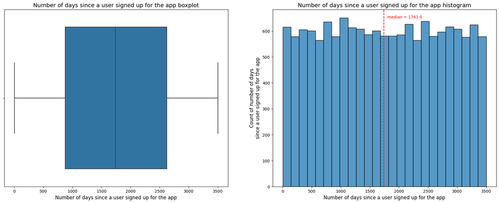

```python
# Set figure and axes

fig, ax = plt.subplots(1, 2, figsize = (22, 8))

# Construct a boxplot showing the number of days since a user signed up for the app

sns.boxplot(data = df, x = 'n_days_after_onboarding', ax = ax[0])
ax[0].set_xlabel('Number of days since a user signed up for the app', fontsize = 12)
ax[0].set_title('Number of days since a user signed up for the app boxplot', fontsize = 14)

# Construct a histogram showing the number of days since a user signed up for the app

sns.histplot(data = df, x = 'n_days_after_onboarding', stat = 'count', ax = ax[1])

median = df['n_days_after_onboarding'].median()
plt.axvline(median, color = 'r', linestyle = '--')
plt.text(1800, 650, 'median = 1741.0', color = 'r')

ax[1].set_xlabel('Number of days since a user signed up for the app', fontsize = 12)
ax[1].set_ylabel('Count of number of days\nsince a user signed up for the app', fontsize = 12)
ax[1].set_title('Number of days since a user signed up for the app histogram', fontsize = 14)

plt.show()
```

#### Comments

The total user tenure (i.e., number of days since onboarding) is a uniform distribution.

#### Analysing total kilometers driven during the month

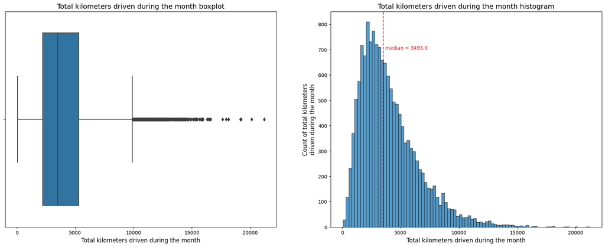

```python
# Set figure and axes

fig, ax = plt.subplots(1, 2, figsize = (22, 8))

# Construct a boxplot showing the total kilometers driven during the month

sns.boxplot(data = df, x = 'driven_km_drives', ax = ax[0])
ax[0].set_xlabel('Total kilometers driven during the month', fontsize = 12)
ax[0].set_title('Total kilometers driven during the month boxplot', fontsize = 14)

# Construct a histogram showing the total kilometers driven during the month

sns.histplot(data = df, x = 'driven_km_drives', stat = 'count', ax = ax[1])

median = df['driven_km_drives'].median()
plt.axvline(median, color = 'r', linestyle = '--')
plt.text(3700, 700, 'median = 3493.9', color = 'r')

ax[1].set_xlabel('Total kilometers driven during the month', fontsize = 12)
ax[1].set_ylabel('Count of total kilometers\ndriven during the month', fontsize = 12)
ax[1].set_title('Total kilometers driven during the month histogram', fontsize = 14)

plt.show()
```

#### Comments

The number of drives driven in the last month per user is a right-skewed distribution with half the users driving under 3,493.9 kilometers.

#### Analysing total duration driven in minutes during the month

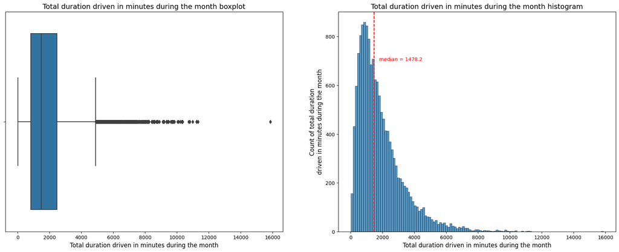

```python
# Set figure and axes

fig, ax = plt.subplots(1, 2, figsize = (22, 8))

# Construct a boxplot showing the total duration driven in minutes during the month

sns.boxplot(data = df, x = 'duration_minutes_drives', ax = ax[0])
ax[0].set_xlabel('Total duration driven in minutes during the month', fontsize = 12)
ax[0].set_title('Total duration driven in minutes during the month boxplot', fontsize = 14)

# Construct a histogram showing the total duration driven in minutes during the month

sns.histplot(data = df, x = 'duration_minutes_drives', stat = 'count', ax = ax[1])

median = df['duration_minutes_drives'].median()
plt.axvline(median, color = 'r', linestyle = '--')
plt.text(1800, 700, 'median = 1478.2', color = 'r')

ax[1].set_xlabel('Total duration driven in minutes during the month', fontsize = 12)
ax[1].set_ylabel('Count of total duration\ndriven in minutes during the month', fontsize = 12)
ax[1].set_title('Total duration driven in minutes during the month histogram', fontsize = 14)

plt.show()
```

#### Comments

The 'duration_minutes_drives' variable has a heavily skewed right tail.

#### Analysing the number of days the user opens the app during the month

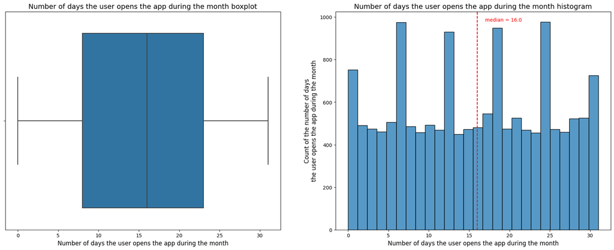

```python
# Set figure and axes

fig, ax = plt.subplots(1, 2, figsize = (22, 8))

# Construct a boxplot showing the number of days the user opens the app during the month

sns.boxplot(data = df, x = 'activity_days', ax = ax[0])
ax[0].set_xlabel('Number of days the user opens the app during the month', fontsize = 12)
ax[0].set_title('Number of days the user opens the app during the month boxplot', fontsize = 14)

# Construct a histogram showing the number of days the user opens the app during the month

sns.histplot(data = df, x = 'activity_days', stat = 'count', ax = ax[1])

median = df['activity_days'].median()
plt.axvline(median, color = 'r', linestyle = '--')
plt.text(17, 980, 'median = 16.0', color = 'r')

ax[1].set_xlabel('Number of days the user opens the app during the month', fontsize = 12)
ax[1].set_ylabel('Count of the number of days\nthe user opens the app during the month', fontsize = 12)
ax[1].set_title('Number of days the user opens the app during the month histogram', fontsize = 14)

plt.show()
```

#### Comments

Within the last month, users opened the app a median of 16 times.

#### Analysing the number of days the user drives (at least 1 km) during the month

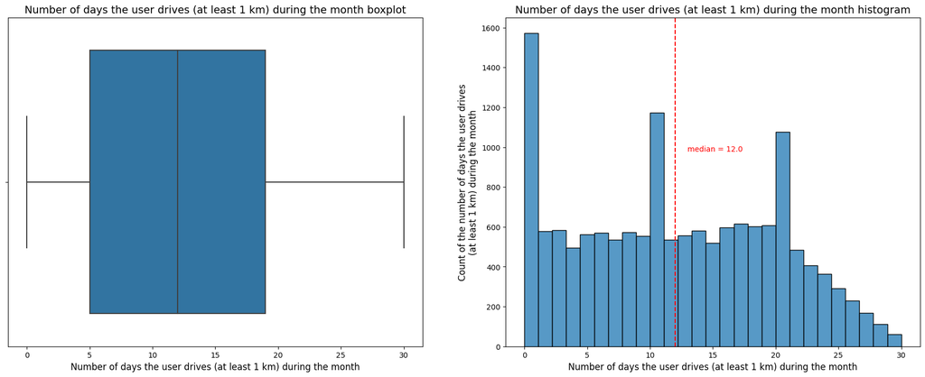

```python
# Set figure and axes

fig, ax = plt.subplots(1, 2, figsize = (22, 8))

# Construct a boxplot showing the number of days the user drives (at least 1 km) during the month

sns.boxplot(data = df, x = 'driving_days', ax = ax[0])
ax[0].set_xlabel('Number of days the user drives (at least 1 km) during the month', fontsize = 12)
ax[0].set_title('Number of days the user drives (at least 1 km) during the month boxplot', fontsize = 14)

# Construct a histogram showing the number of days the user drives (at least 1 km) during the month

sns.histplot(data = df, x = 'driving_days', stat = 'count', ax = ax[1])

median = df['driving_days'].median()
plt.axvline(median, color = 'r', linestyle = '--')
plt.text(13, 980, 'median = 12.0', color = 'r')

ax[1].set_xlabel('Number of days the user drives (at least 1 km) during the month', fontsize = 12)
ax[1].set_ylabel('Count of the number of days the user drives\n(at least 1 km) during the month', fontsize = 12)
ax[1].set_title('Number of days the user drives (at least 1 km) during the month histogram', fontsize = 14)

plt.show()
```

#### Analysing device type

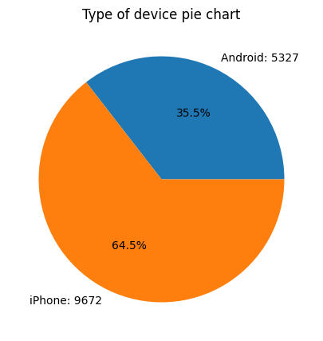

```python
# Construct a pie chart showing the type of device a user starts a session with

plt.figure(figsize = (10, 5))

type_of_device = df.groupby(['device']).device.count()
type_of_device.plot(kind = 'pie', y = 'type_of_device', autopct = '%1.1f%%',
                    labels = [f'{type_of_device.index[0]}: {type_of_device.values[0]}',
                              f'{type_of_device.index[1]}: {type_of_device.values[1]}'])


plt.ylabel('')
plt.title('Type of device pie chart')

plt.show()
```

#### Comments

There are nearly twice as many iPhone users as Android users represented in this data.

#### Analysing if a user has churned

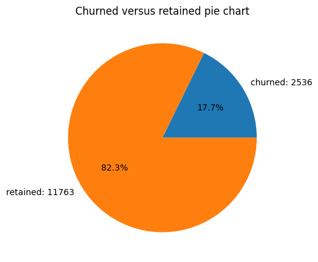

```python
# Construct a pie chart showing if a user has churned anytime during the course of the month

plt.figure(figsize = (10, 5))

churned_or_retained = df.groupby(['label']).label.count()
churned_or_retained.plot(kind = 'pie', y = 'churned_or_retained', autopct = '%1.1f%%',
                    labels = [f'{churned_or_retained.index[0]}: {churned_or_retained.values[0]}',
                              f'{churned_or_retained.index[1]}: {churned_or_retained.values[1]}'])


plt.ylabel('')
plt.title('Churned versus retained pie chart')

plt.show()
```

#### Comments

Less than 18% of the users churned.

#### Analysing 'driving_days' versus 'activity_days'

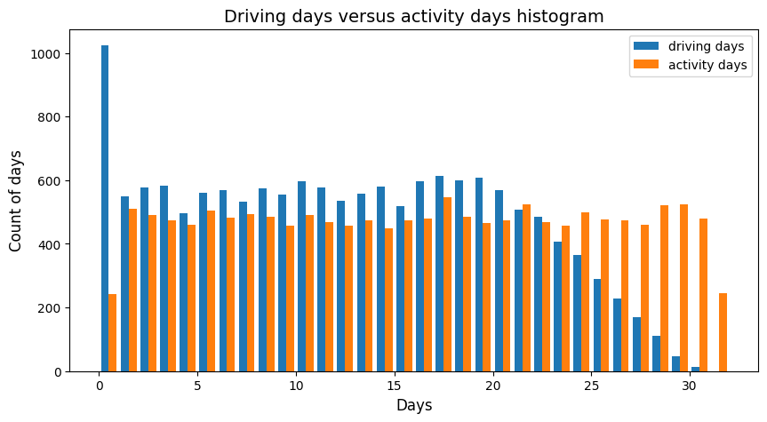

```python
# Construct a histogram showing the counts of 'driving_days' and 'activity_days'

plt.figure(figsize = (10, 5))

label = ['driving days', 'activity days']

plt.hist([df['driving_days'], df['activity_days']],
         bins = range(0,33),
         label = label)

plt.xlabel('Days', fontsize = 12)
plt.ylabel('Count of days', fontsize = 12)
plt.legend()
plt.title('Driving days versus activity days histogram', fontsize = 14)

plt.show()
```

#### Comments

There are fewer people who did not use the app at all during the month and more people who did not drive at all during the month.

```python
print('Max number of driving days:', df['driving_days'].max())
print('Max number of activity days:', df['activity_days'].max())
```

```
Max number of driving days: 30
Max number of activity days: 31
```

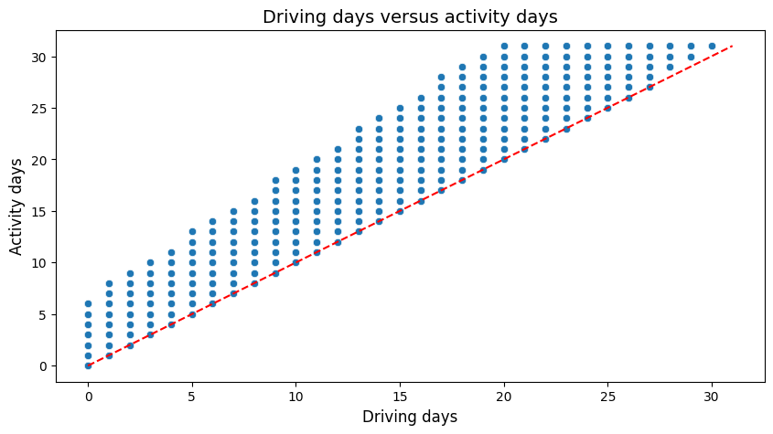

```python
# Construct a scatter plot showing 'driving_days' versus 'activity_days'

plt.figure(figsize = (10, 5))
sns.scatterplot(data = df, x = 'driving_days', y = 'activity_days')

plt.xlabel('Driving days', fontsize = 12)
plt.ylabel('Activity days', fontsize = 12)
plt.title('Driving days versus activity days', fontsize = 14)

plt.plot([0,31], [0,31], color = 'r', linestyle = '--')

plt.show()
```

#### Analysing retention by device

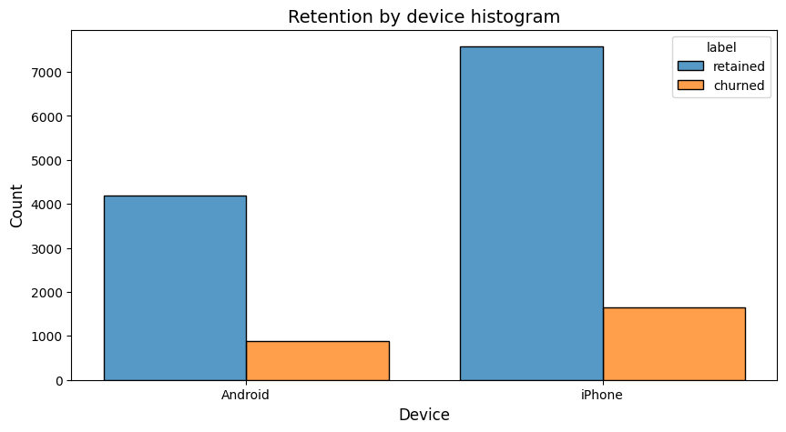

```python
# Construct a histogram showing the retention by device

plt.figure(figsize = (10, 5))

sns.histplot(data = df, x = 'device', hue = 'label', multiple = 'dodge', shrink = 0.8)

plt.xlabel('Device', fontsize = 12)
plt.ylabel('Count', fontsize = 12)
plt.title('Retention by device histogram', fontsize = 14)

plt.show()
```

#### Comments

The proportion of churned users to retained users is consistent between device types.

#### Analysing retention by kilometers driven per driving day

```python
# Create 'km_per_driving_day' column

df['km_per_driving_day'] = df['driven_km_drives'] / df['driving_days']

# Explore the new column

df['km_per_driving_day'].describe()
```

```
count    1.499900e+04
mean              inf
std               NaN
min      3.022063e+00
25%      1.672804e+02
50%      3.231459e+02
75%      7.579257e+02
max               inf
Name: km_per_driving_day, dtype: float64
```

#### Comments

The mean value is infinity, the standard deviation is NaN, and the max value is infinity, because there are values of zero in the 'driving_days' column.

```python
# Convert infinite values to zero

df.loc[df['km_per_driving_day'] == np.inf, 'km_per_driving_day'] = 0

# Confirm that it worked

df['km_per_driving_day'].describe()
```

```
count    14999.000000
mean       578.963113
std       1030.094384
min          0.000000
25%        136.238895
50%        272.889272
75%        558.686918
max      15420.234110
Name: km_per_driving_day, dtype: float64
```

#### Comments

The maximum value is 15,420 kilometers per drive day. That does not seem plausible.

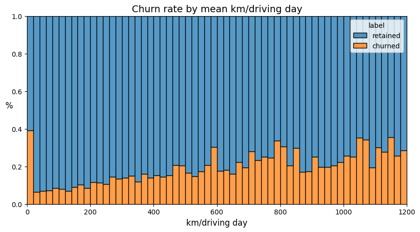

```python
# Construct a histogram of the 'km_per_driving_day' column, disregarding those users with values greater than 1,200 km

plt.figure(figsize = (10, 5))

sns.histplot(data = df, x = 'km_per_driving_day', bins = range(0, 1201, 20), hue = 'label', multiple = 'fill')

plt.xlabel('km/driving day', fontsize = 12)
plt.ylabel('%', rotation = 0, fontsize = 12)
plt.title('Churn rate by mean km/driving day', fontsize = 14)

plt.show()
```

#### Analysing retention by 'driving_days'

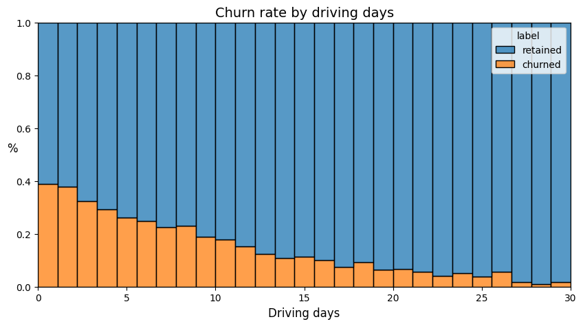

```python
# Construct a histogram of the 'driving_days' column

plt.figure(figsize = (10, 5))

sns.histplot(data = df, x = 'driving_days', hue = 'label', multiple = 'fill')

plt.xlabel('Driving days', fontsize = 12)
plt.ylabel('%', rotation = 0, fontsize = 12)
plt.title('Churn rate by driving days', fontsize = 14)

plt.show()
```

#### Comments

The churn rate is highest for people who did not use Waze much during the last month. The more times they used the app, the less likely they were to churn.

#### Analysing proportion of sessions that occurred in the last month

```python
# Create a new column 'percent_sessions_in_last_month',
# that represents the percentage of each user's total sessions that were logged in their last month of use

df['percent_sessions_in_last_month'] = df['sessions'] / df['total_sessions']
```

```python
# Find the median value of the new column

df['percent_sessions_in_last_month'].median()
```

```
0.42309702992763176
```

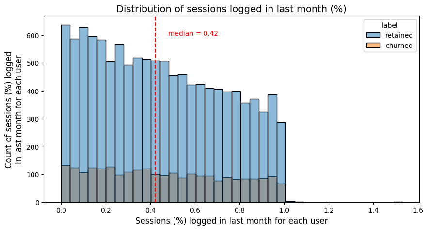

```python
# Consctruct a histogram showing the distribution of values in the 'percent_sessions_in_last_month' column

plt.figure(figsize = (10, 5))

sns.histplot(data = df, x = 'percent_sessions_in_last_month', hue = 'label', multiple = 'layer')

median = df['percent_sessions_in_last_month'].median()
plt.axvline(median, color = 'r', linestyle = '--')
plt.text(0.48, 600, 'median = 0.42', color = 'r')

plt.xlabel('Sessions (%) logged in last month for each user', fontsize = 12)
plt.ylabel('Count of sessions (%) logged\nin last month for each user', fontsize = 12)
plt.title('Distribution of sessions logged in last month (%)', fontsize = 14)

plt.show()
```

```python
# Find the median value of the 'n_days_after_onboarding' column

df['n_days_after_onboarding'].median()
```

```
1741.0
```

#### Comments

Half of the people in the dataset had 40% or more of their sessions in just the last month, yet the overall median time since onboarding is almost five years.

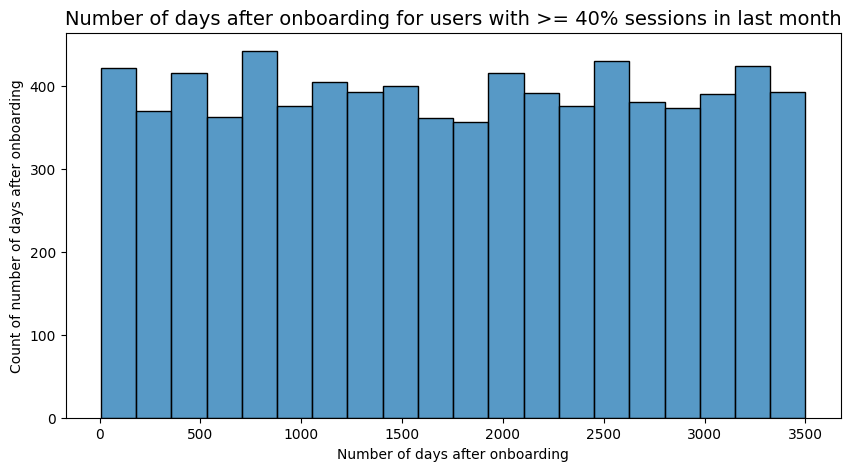

```python
# Construct a histogram of 'n_days_after_onboarding' for just the people who had 40% or more of their total sessions in the last month

data = df.loc[df['percent_sessions_in_last_month'] >= 0.4]

plt.figure(figsize = (10, 5))

sns.histplot(x = data['n_days_after_onboarding'])

plt.xlabel('Number of days after onboarding')
plt.ylabel('Count of number of days after onboarding')
plt.title('Number of days after onboarding for users with >= 40% sessions in last month', fontsize = 14)

plt.show()
```

#### Comments

Many long-time users suddenly used the app more often in the last month.

#### Outliers

The box plots above indicated that many of the variables have outliers.

```python
# Write a function that calculates the 95th percentile of a given column

def outlier_imputer(column_name, percentile):
    threshold = df[column_name].quantile(percentile)   # Calculate threshold
    df.loc[df[column_name] > threshold, column_name] = threshold # Impute threshold for values > than threshold

    print('{:>25} | percentile: {} | threshold: {}'.format(column_name, percentile, threshold))
```

```python
# Apply the above function to the following columns

for column in ['sessions', 'drives', 'total_sessions',
               'driven_km_drives', 'duration_minutes_drives']:
               outlier_imputer(column, 0.95)
```

```
                 sessions | percentile: 0.95 | threshold: 243.0
                   drives | percentile: 0.95 | threshold: 201.0
           total_sessions | percentile: 0.95 | threshold: 454.3632037399997
         driven_km_drives | percentile: 0.95 | threshold: 8889.7942356
  duration_minutes_drives | percentile: 0.95 | threshold: 4668.899348999998
```

```python
df.describe()
```

|  | ID | sessions | drives | total_sessions | n_days_after_onboarding | total_navigations_fav1 | total_navigations_fav2 | driven_km_drives | duration_minutes_drives | activity_days | driving_days | km_per_drive | km_per_driving_day | drives_per_driving_day | percent_sessions_in_last_month |
| --- | --- | --- | --- | --- | --- | --- | --- | --- | --- | --- | --- | --- | --- | --- | --- |
| count | 14999.000000 | 14999.000000 | 14999.000000 | 14999.000000 | 14999.000000 | 14999.000000 | 14999.000000 | 14999.000000 | 14999.000000 | 14999.000000 | 14999.000000 | 1.499900e+04 | 14999.000000 | 1.499200e+04 | 14999.000000 |
| mean | 7499.000000 | 76.568705 | 64.058204 | 184.031320 | 1749.837789 | 121.605974 | 29.672512 | 3939.632764 | 1789.647426 | 15.537102 | 12.179879 | inf | 578.963113 | inf | 0.449255 |
| std | 4329.982679 | 67.297958 | 55.306924 | 118.600463 | 1008.513876 | 148.121544 | 45.394651 | 2216.041510 | 1222.705167 | 9.004655 | 7.824036 | NaN | 1030.094384 | NaN | 0.286919 |
| min | 0.000000 | 0.000000 | 0.000000 | 0.220211 | 4.000000 | 0.000000 | 0.000000 | 60.441250 | 18.282082 | 0.000000 | 0.000000 | 1.008775e+00 | 0.000000 | 0.000000e+00 | 0.000000 |
| 25% | 3749.500000 | 23.000000 | 20.000000 | 90.661156 | 878.000000 | 9.000000 | 0.000000 | 2212.600607 | 835.996260 | 8.000000 | 5.000000 | 3.323065e+01 | 136.238895 | 1.800000e+00 | 0.196221 |
| 50% | 7499.000000 | 56.000000 | 48.000000 | 159.568115 | 1741.000000 | 71.000000 | 9.000000 | 3493.858085 | 1478.249859 | 16.000000 | 12.000000 | 7.488006e+01 | 272.889272 | 4.666667e+00 | 0.423097 |
| 75% | 11248.500000 | 112.000000 | 93.000000 | 254.192341 | 2623.500000 | 178.000000 | 43.000000 | 5289.861262 | 2464.362632 | 23.000000 | 19.000000 | 1.854667e+02 | 558.686918 | 1.216667e+01 | 0.687216 |
| max | 14998.000000 | 243.000000 | 201.000000 | 454.363204 | 3500.000000 | 1236.000000 | 415.000000 | 8889.794236 | 4668.899349 | 31.000000 | 30.000000 | inf | 15420.234110 | inf | 1.530637 |

#### Comments

The overall churn rate is ~17%, and this rate is consistent between iPhone users and Android users. Users who drive very long distances on their driving days are more likely to churn, but users who drive more often are less likely to churn.

```python
# Delete unnecessary column

df.drop('drives_per_driving_day', inplace = True, axis = 1)
```

```python
df.info()
```

```
<class 'pandas.core.frame.DataFrame'>
RangeIndex: 14999 entries, 0 to 14998
Data columns (total 16 columns):
 #   Column                          Non-Null Count  Dtype
---  ------                          --------------  -----
 0   ID                              14999 non-null  int64
 1   label                           14299 non-null  object
 2   sessions                        14999 non-null  int64
 3   drives                          14999 non-null  int64
 4   total_sessions                  14999 non-null  float64
 5   n_days_after_onboarding         14999 non-null  int64
 6   total_navigations_fav1          14999 non-null  int64
 7   total_navigations_fav2          14999 non-null  int64
 8   driven_km_drives                14999 non-null  float64
 9   duration_minutes_drives         14999 non-null  float64
 10  activity_days                   14999 non-null  int64
 11  driving_days                    14999 non-null  int64
 12  device                          14999 non-null  object
 13  km_per_drive                    14999 non-null  float64
 14  km_per_driving_day              14999 non-null  float64
 15  percent_sessions_in_last_month  14999 non-null  float64
dtypes: float64(6), int64(8), object(2)
memory usage: 1.8+ MB
```

```python
# Create 'map_dictionary'

map_dictionary = {'Android': 2, 'iPhone': 1}

# Create new 'device_type' column

df['device_type'] = df['device']

# Map the new column to the dictionary

df['device_type'] = df['device_type'].map(map_dictionary)

df.head()
```

|  | ID | label | sessions | drives | total_sessions | n_days_after_onboarding | total_navigations_fav1 | total_navigations_fav2 | driven_km_drives | duration_minutes_drives | activity_days | driving_days | device | km_per_drive | km_per_driving_day | percent_sessions_in_last_month | device_type |
| --- | --- | --- | --- | --- | --- | --- | --- | --- | --- | --- | --- | --- | --- | --- | --- | --- | --- |
| 0 | 0 | retained | 243 | 201 | 296.748273 | 2276 | 208 | 0 | 2628.845068 | 1985.775061 | 28 | 19 | Android | 11.632058 | 138.360267 | 0.953670 | 2 |
| 1 | 1 | retained | 133 | 107 | 326.896596 | 1225 | 19 | 64 | 8889.794236 | 3160.472914 | 13 | 11 | iPhone | 128.186173 | 1246.901868 | 0.406856 | 1 |
| 2 | 2 | retained | 114 | 95 | 135.522926 | 2651 | 0 | 0 | 3059.148818 | 1610.735904 | 14 | 8 | Android | 32.201567 | 382.393602 | 0.841186 | 2 |
| 3 | 3 | retained | 49 | 40 | 67.589221 | 15 | 322 | 7 | 913.591123 | 587.196542 | 7 | 3 | iPhone | 22.839778 | 304.530374 | 0.724968 | 1 |
| 4 | 4 | retained | 84 | 68 | 168.247020 | 1562 | 166 | 5 | 3950.202008 | 1219.555924 | 27 | 18 | Android | 58.091206 | 219.455667 | 0.499266 | 2 |

```python
# Find the average number of drives for each device type

df.groupby('device_type')['drives'].mean()
```

```
device_type
1    64.446340
2    63.353482
Name: drives, dtype: float64
```

#### Comments

Based on the averages shown, it appears that drivers who use an iPhone device have a higher number of drives on average. To assess whether the difference is statistically significant I will conduct a hypothesis test.

### 3. Hypothesis testing

The goal is to conduct a two-sample t-test. The steps for conducting a hypothesis test:

(1)State the null hypothesis and the alternative hypothesis

(2)Choose a significance level

(3)Find the p-value

(4)Reject or fail to reject the null hypothesis

- This is a t-test for two independent samples. This is the appropriate test since the two groups are independent (Android users vs. iPhone users).
- $H_0$: There is no difference in average number of drives between drivers who use iPhone devices and drivers who use Androids.
- $H_A$: There is a difference in average number of drives between drivers who use iPhone devices and drivers who use Androids.
- I choose 5% as the significance level.

```python
# Isolate the 'drives' column for iPhone users

iPhone = df[df['device_type'] == 1]['drives']

# Isolate the 'drives' column for Android users

Android = df[df['device_type'] == 2]['drives']

# Perform the t-test

stats.ttest_ind(a = iPhone, b = Android, equal_var = False)
```

```
TtestResult(statistic=1.1643714136026293, pvalue=0.24429844267242223, df=11148.669519764011)
```

#### Comments

Since the p-value is larger than the chosen significance level (5%), I fail to reject the null hypothesis. I conclude that there is not a statistically significant difference in the average number of drives between drivers who use iPhones and drivers who use Androids.

```python
# Remove the ID column since it is not needed for the analysis

df = df.drop('ID', axis = 1)
```

```python
# Check the class balance of the dependent (target) variable, 'label'

df['label'].value_counts(normalize=True)
```

```
label
retained    0.822645
churned     0.177355
Name: proportion, dtype: float64
```

```python
df.describe()
```

|  | sessions | drives | total_sessions | n_days_after_onboarding | total_navigations_fav1 | total_navigations_fav2 | driven_km_drives | duration_minutes_drives | activity_days | driving_days | km_per_drive | km_per_driving_day | percent_sessions_in_last_month | device_type |
| --- | --- | --- | --- | --- | --- | --- | --- | --- | --- | --- | --- | --- | --- | --- |
| count | 14999.000000 | 14999.000000 | 14999.000000 | 14999.000000 | 14999.000000 | 14999.000000 | 14999.000000 | 14999.000000 | 14999.000000 | 14999.000000 | 1.499900e+04 | 14999.000000 | 14999.000000 | 14999.000000 |
| mean | 76.568705 | 64.058204 | 184.031320 | 1749.837789 | 121.605974 | 29.672512 | 3939.632764 | 1789.647426 | 15.537102 | 12.179879 | inf | 578.963113 | 0.449255 | 1.355157 |
| std | 67.297958 | 55.306924 | 118.600463 | 1008.513876 | 148.121544 | 45.394651 | 2216.041510 | 1222.705167 | 9.004655 | 7.824036 | NaN | 1030.094384 | 0.286919 | 0.478577 |
| min | 0.000000 | 0.000000 | 0.220211 | 4.000000 | 0.000000 | 0.000000 | 60.441250 | 18.282082 | 0.000000 | 0.000000 | 1.008775e+00 | 0.000000 | 0.000000 | 1.000000 |
| 25% | 23.000000 | 20.000000 | 90.661156 | 878.000000 | 9.000000 | 0.000000 | 2212.600607 | 835.996260 | 8.000000 | 5.000000 | 3.323065e+01 | 136.238895 | 0.196221 | 1.000000 |
| 50% | 56.000000 | 48.000000 | 159.568115 | 1741.000000 | 71.000000 | 9.000000 | 3493.858085 | 1478.249859 | 16.000000 | 12.000000 | 7.488006e+01 | 272.889272 | 0.423097 | 1.000000 |
| 75% | 112.000000 | 93.000000 | 254.192341 | 2623.500000 | 178.000000 | 43.000000 | 5289.861262 | 2464.362632 | 23.000000 | 19.000000 | 1.854667e+02 | 558.686918 | 0.687216 | 2.000000 |
| max | 243.000000 | 201.000000 | 454.363204 | 3500.000000 | 1236.000000 | 415.000000 | 8889.794236 | 4668.899349 | 31.000000 | 30.000000 | inf | 15420.234110 | 1.530637 | 2.000000 |

#### Comments

The following columns all seem to have outliers:

- sessions
- drives
- total_sessions
- total_navigations_fav1
- total_navigations_fav2
- driven_km_drives
- duration_minutes_drives

All of these columns have max values that are multiple standard deviations above the 75th percentile. This could indicate outliers in these variables.

```python
# Convert infinite values to zero

df.loc[df['km_per_drive'] == np.inf, 'km_per_drive'] = 0

df['km_per_drive'].describe()
```

```
count    14999.000000
mean       232.817946
std        620.622351
min          0.000000
25%         32.424301
50%         72.854343
75%        179.347527
max      15777.426560
Name: km_per_drive, dtype: float64
```

```python
# Create 'professional_driver' column

df['professional_driver'] = np.where((df['drives'] >= 60) & (df['driving_days'] >= 15), 1, 0)
```

```python
# Check count of professionals and non-professionals

print(df['professional_driver'].value_counts())

# Check in-class churn rate

df.groupby(['professional_driver'])['label'].value_counts(normalize = True)
```

```
professional_driver
0    12405
1     2594
Name: count, dtype: int64
```

```
professional_driver  label
0                    retained    0.801202
                     churned     0.198798
1                    retained    0.924437
                     churned     0.075563
Name: proportion, dtype: float64
```

#### Comments

The churn rate for professional drivers is 7.6%, while the churn rate for non-professionals is 19.9%.

```python
df.info()
```

```
<class 'pandas.core.frame.DataFrame'>
RangeIndex: 14999 entries, 0 to 14998
Data columns (total 17 columns):
 #   Column                          Non-Null Count  Dtype
---  ------                          --------------  -----
 0   label                           14299 non-null  object
 1   sessions                        14999 non-null  int64
 2   drives                          14999 non-null  int64
 3   total_sessions                  14999 non-null  float64
 4   n_days_after_onboarding         14999 non-null  int64
 5   total_navigations_fav1          14999 non-null  int64
 6   total_navigations_fav2          14999 non-null  int64
 7   driven_km_drives                14999 non-null  float64
 8   duration_minutes_drives         14999 non-null  float64
 9   activity_days                   14999 non-null  int64
 10  driving_days                    14999 non-null  int64
 11  device                          14999 non-null  object
 12  km_per_drive                    14999 non-null  float64
 13  km_per_driving_day              14999 non-null  float64
 14  percent_sessions_in_last_month  14999 non-null  float64
 15  device_type                     14999 non-null  int64
 16  professional_driver             14999 non-null  int32
dtypes: float64(6), int32(1), int64(8), object(2)
memory usage: 1.9+ MB
```

```python
# Drop rows with missing data in the 'label' column

df = df.dropna(subset = ['label'])
```

```python
# Impute the outlying values for the columns;
# Calculate the 95th percentile of each column;
# Change to this value any value in the column that exceeds it

for column in ['sessions', 'drives', 'total_sessions', 'total_navigations_fav1',
               'total_navigations_fav2', 'driven_km_drives', 'duration_minutes_drives']:
    threshold = df[column].quantile(0.95)
    df.loc[df[column] > threshold, column] = threshold
```

```python
# Encode categorical variables by creating binary 'label2' column, where 0 stands for all retained users and 1 stands for all churned users

df['label2'] = np.where((df['label'] == 'retained'), 0, 1)

df[['label', 'label2']].tail()
```

|  | label | label2 |
| --- | --- | --- |
| 14994 | retained | 0 |
| 14995 | retained | 0 |
| 14996 | retained | 0 |
| 14997 | churned | 1 |
| 14998 | retained | 0 |

```python
# Generate a correlation matrix

df.corr(method = 'pearson', numeric_only = True)
```

|  | sessions | drives | total_sessions | n_days_after_onboarding | total_navigations_fav1 | total_navigations_fav2 | driven_km_drives | duration_minutes_drives | activity_days | driving_days | km_per_drive | km_per_driving_day | percent_sessions_in_last_month | device_type | professional_driver | label2 |
| --- | --- | --- | --- | --- | --- | --- | --- | --- | --- | --- | --- | --- | --- | --- | --- | --- |
| sessions | 1.000000 | 0.996942 | 0.597299 | 0.007101 | 0.001858 | 0.008536 | 0.002995 | -0.004545 | 0.025113 | 0.020294 | -0.316930 | -0.011569 | 0.614136 | -0.012704 | 0.443654 | 0.034911 |
| drives | 0.996942 | 1.000000 | 0.595396 | 0.006940 | 0.001058 | 0.009505 | 0.003445 | -0.003889 | 0.024357 | 0.019608 | -0.320554 | -0.010989 | 0.614282 | -0.011684 | 0.444425 | 0.035865 |
| total_sessions | 0.597299 | 0.595396 | 1.000000 | 0.006615 | 0.000194 | 0.010363 | 0.001015 | -0.000345 | 0.015757 | 0.012957 | -0.191790 | -0.016162 | -0.113455 | -0.012133 | 0.254532 | 0.024568 |
| n_days_after_onboarding | 0.007101 | 0.006940 | 0.006615 | 1.000000 | -0.002450 | -0.004968 | -0.004655 | -0.010167 | -0.009418 | -0.007321 | 0.004090 | 0.011764 | -0.000874 | 0.011299 | 0.003770 | -0.129263 |
| total_navigations_fav1 | 0.001858 | 0.001058 | 0.000194 | -0.002450 | 1.000000 | 0.002866 | -0.007365 | 0.005646 | 0.010902 | 0.010419 | -0.005389 | -0.000197 | 0.015180 | 0.001316 | -0.000224 | 0.052322 |
| total_navigations_fav2 | 0.008536 | 0.009505 | 0.010363 | -0.004968 | 0.002866 | 1.000000 | 0.003567 | -0.003009 | -0.004425 | 0.002000 | 0.003198 | 0.006751 | 0.000603 | 0.000275 | 0.007126 | 0.015032 |
| driven_km_drives | 0.002995 | 0.003445 | 0.001015 | -0.004655 | -0.007365 | 0.003567 | 1.000000 | 0.690547 | -0.007445 | -0.009550 | 0.225866 | 0.344765 | -0.002088 | 0.002086 | -0.000901 | 0.019771 |
| duration_minutes_drives | -0.004545 | -0.003889 | -0.000345 | -0.010167 | 0.005646 | -0.003009 | 0.690547 | 1.000000 | -0.007895 | -0.009425 | 0.169051 | 0.239627 | -0.007884 | 0.007709 | -0.012128 | 0.040407 |
| activity_days | 0.025113 | 0.024357 | 0.015757 | -0.009418 | 0.010902 | -0.004425 | -0.007445 | -0.007895 | 1.000000 | 0.947687 | -0.005193 | -0.397433 | 0.017840 | 0.010221 | 0.453825 | -0.303851 |
| driving_days | 0.020294 | 0.019608 | 0.012957 | -0.007321 | 0.010419 | 0.002000 | -0.009550 | -0.009425 | 0.947687 | 1.000000 | -0.004005 | -0.407917 | 0.013550 | 0.003859 | 0.469776 | -0.294259 |
| km_per_drive | -0.316930 | -0.320554 | -0.191790 | 0.004090 | -0.005389 | 0.003198 | 0.225866 | 0.169051 | -0.005193 | -0.004005 | 1.000000 | 0.095109 | -0.323536 | -0.002534 | -0.143732 | -0.000236 |
| km_per_driving_day | -0.011569 | -0.010989 | -0.016162 | 0.011764 | -0.000197 | 0.006751 | 0.344765 | 0.239627 | -0.397433 | -0.407917 | 0.095109 | 1.000000 | -0.006958 | -0.002979 | -0.165966 | 0.148583 |
| percent_sessions_in_last_month | 0.614136 | 0.614282 | -0.113455 | -0.000874 | 0.015180 | 0.000603 | -0.002088 | -0.007884 | 0.017840 | 0.013550 | -0.323536 | -0.006958 | 1.000000 | -0.003460 | 0.295284 | 0.018018 |
| device_type | -0.012704 | -0.011684 | -0.012133 | 0.011299 | 0.001316 | 0.000275 | 0.002086 | 0.007709 | 0.010221 | 0.003859 | -0.002534 | -0.002979 | -0.003460 | 1.000000 | -0.007274 | -0.003406 |
| professional_driver | 0.443654 | 0.444425 | 0.254532 | 0.003770 | -0.000224 | 0.007126 | -0.000901 | -0.012128 | 0.453825 | 0.469776 | -0.143732 | -0.165966 | 0.295284 | -0.007274 | 1.000000 | -0.122312 |
| label2 | 0.034911 | 0.035865 | 0.024568 | -0.129263 | 0.052322 | 0.015032 | 0.019771 | 0.040407 | -0.303851 | -0.294259 | -0.000236 | 0.148583 | 0.018018 | -0.003406 | -0.122312 | 1.000000 |

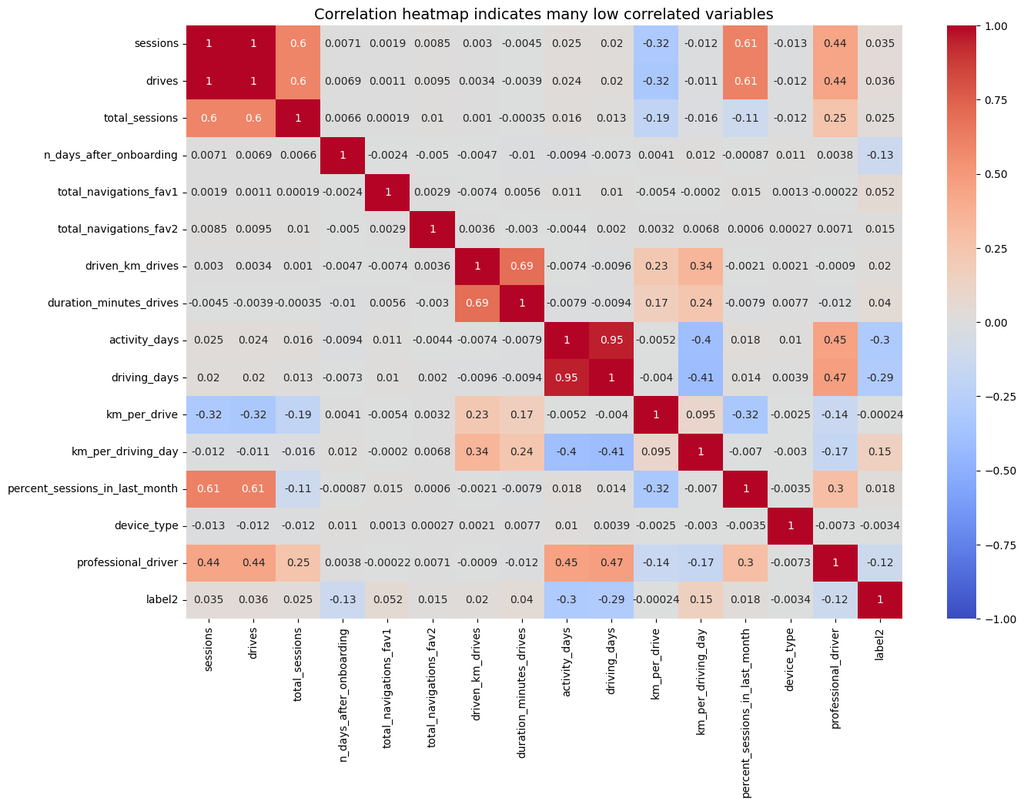

```python
# Plot correlation heatmap

plt.figure(figsize = (15, 10))

sns.heatmap(df.corr(method = 'pearson', numeric_only = True), vmin = -1, vmax = 1, annot = True, cmap = 'coolwarm')

plt.title('Correlation heatmap indicates many low correlated variables', fontsize = 14)

plt.show()
```

#### Comments

If there are predictor variables that have a Pearson correlation coefficient value greater than the absolute value of 0.7, these variables are strongly multicollinear. Therefore, only one of these variables should be used in the model.

Hence, the below variables are multicollinear with each other:

- sessions and drives: 1.0
- driving_days and activity_days: 0.95

```python
# Create new 'device2' variable, where 0 stands for Android and 1 stands for iPhone

df['device2'] = np.where((df['device'] == 'Android'), 0, 1)

df[['device', 'device2']].tail()
```

|  | device | device2 |
| --- | --- | --- |
| 14994 | iPhone | 1 |
| 14995 | Android | 0 |
| 14996 | iPhone | 1 |
| 14997 | iPhone | 1 |
| 14998 | iPhone | 1 |

### 4. Building a logistic regression model

```python
# Isolate predictor variables

X = df.drop(columns = ['label', 'label2', 'device', 'sessions', 'driving_days'])
```

```python
# Isolate target variable

y = df['label2']
```

```python
# Perform the train-test split

X_train, X_test, y_train, y_test = train_test_split(X, y, stratify = y, random_state = 42)

X_train.head()
```

|  | drives | total_sessions | n_days_after_onboarding | total_navigations_fav1 | total_navigations_fav2 | driven_km_drives | duration_minutes_drives | activity_days | km_per_drive | km_per_driving_day | percent_sessions_in_last_month | device_type | professional_driver | device2 |
| --- | --- | --- | --- | --- | --- | --- | --- | --- | --- | --- | --- | --- | --- | --- |
| 152 | 108 | 186.192746 | 3116 | 243 | 124 | 8889.794236 | 4668.180092 | 24 | 85.042481 | 612.305861 | 0.698201 | 1 | 1 | 1 |
| 11899 | 2 | 3.487590 | 794 | 114 | 18 | 3286.545691 | 1780.902733 | 5 | 1643.272845 | 3286.545691 | 0.573462 | 1 | 0 | 1 |
| 10937 | 139 | 347.106403 | 331 | 4 | 7 | 7400.838975 | 2349.305267 | 15 | 53.243446 | 616.736581 | 0.492644 | 2 | 0 | 0 |
| 669 | 108 | 454.363204 | 2320 | 11 | 4 | 6566.424830 | 4558.459870 | 18 | 60.800230 | 410.401552 | 0.272322 | 1 | 1 | 1 |
| 8406 | 10 | 89.475821 | 2478 | 135 | 0 | 1271.248661 | 938.711572 | 27 | 127.124866 | 74.779333 | 0.111762 | 1 | 0 | 1 |

```python
# Instantiate a logistic regression model

model = LogisticRegression(penalty = None, max_iter = 400)

# Fit the model on 'X_train' and 'y_train'

model.fit(X_train, y_train)
```

```
LogisticRegression(max_iter=400, penalty=None)
```

```python
# Get the coefficients of each variable
# Coefficients represent the change in the log odds of the target variable for every one unit increase in X

pd.Series(model.coef_[0], index = X.columns)
```

```
drives                            0.002318
total_sessions                    0.000306
n_days_after_onboarding          -0.000410
total_navigations_fav1            0.001225
total_navigations_fav2            0.000902
driven_km_drives                 -0.000022
duration_minutes_drives           0.000108
activity_days                    -0.106464
km_per_drive                      0.000114
km_per_driving_day                0.000016
percent_sessions_in_last_month   -0.000746
device_type                      -0.002388
professional_driver              -0.001532
device2                          -0.001048
dtype: float64
```

```python
model.intercept_
```

```
array([-0.00171774])
```

```python
# Get the predicted probabilities of the training data

training_probabilities = model.predict_proba(X_train)
training_probabilities
```

```
array([[0.94240326, 0.05759674],
       [0.58445277, 0.41554723],
       [0.76733746, 0.23266254],
       ...,
       [0.92215602, 0.07784398],
       [0.85103911, 0.14896089],
       [0.93542086, 0.06457914]])
```

#### Comments

In the above 2-D array, each row represents a user in 'X_train'. The first column is the probability of the user not churning, and the second column is the probability of the user churning

In logistic regression, the relationship between a predictor variable and the dependent variable does not need to be linear, however, the log-odds (a.k.a., logit) of the dependent variable with respect to the predictor variable should be linear. Here is the formula for calculating log-odds, where *p* is the probability of response:

$$ logit(p) = ln(\frac{p}{1-p}) $$

```python
# Copy the 'X_train' dataframe and assign to 'logit_data'

logit_data = X_train.copy()

# Create a new 'logit' column in the 'logit_data' dataframe

logit_data['logit'] = [np.log(prob[1] / prob[0]) for prob in training_probabilities]
```

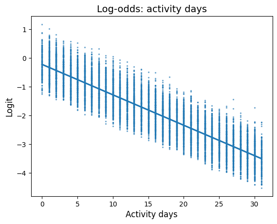

```python
# Plot regplot of 'activity_days' log-odds

sns.regplot(x = 'activity_days', y = 'logit', data = logit_data, scatter_kws = {'s': 2, 'alpha': 0.5})

plt.xlabel('Activity days', fontsize = 12)
plt.ylabel('Logit', fontsize = 12)
plt.title('Log-odds: activity days', fontsize = 14)

plt.show()
```

```python
# Generate predictions on 'X_test'

y_preds = model.predict(X_test)
```

```python
# Score the model (accuracy) on the test data

model.score(X_test, y_test)
```

```
0.8234965034965035
```

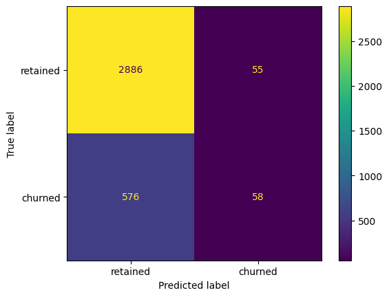

```python
# Create confusion matrix

cm = confusion_matrix(y_test, y_preds)

disp = ConfusionMatrixDisplay(confusion_matrix = cm,
                              display_labels = ['retained', 'churned'],
                              )
disp.plot()

plt.show()
```

```python
# Calculate precision manually

precision = cm[1, 1] / (cm[0, 1] + cm[1, 1])
precision
```

```
0.5132743362831859
```

```python
# Calculate recall manually

recall = cm[1, 1] / (cm[1, 0] + cm[1, 1])
recall
```

```
0.0914826498422713
```

```python
# Create a classification report

target_labels = ['retained', 'churned']

print(classification_report(y_test, y_preds, target_names = target_labels))
```

```
              precision    recall  f1-score   support

    retained       0.83      0.98      0.90      2941
     churned       0.51      0.09      0.16       634

    accuracy                           0.82      3575
   macro avg       0.67      0.54      0.53      3575
weighted avg       0.78      0.82      0.77      3575
```

#### Comments

The model has decent precision but very low recall, which means that it makes a lot of false negative predictions and fails to capture users who will churn.

[output not shown]

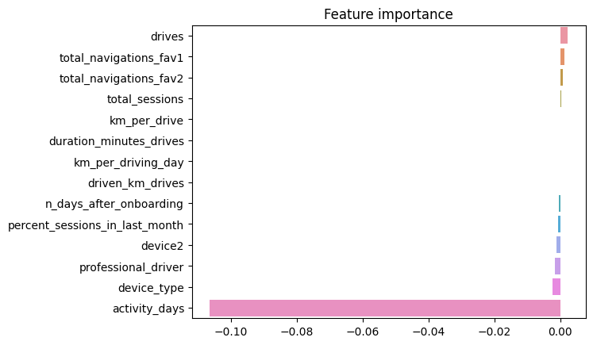

```python
# Generate a bar graph of the model's coefficients for a visual representation of the importance of the model's features

# Create a list of (column_name, coefficient) tuples

feature_importance = list(zip(X_train.columns, model.coef_[0]))

# Sort the list by coefficient value

feature_importance = sorted(feature_importance, key = lambda x: x[1], reverse = True)
print(feature_importance)

# Plot the feature importances

import seaborn as sns
sns.barplot(x = [x[1] for x in feature_importance],
            y = [x[0] for x in feature_importance],
            orient = 'h')

plt.title('Feature importance')

plt.show()
```

```python
# Create `total_sessions_per_day` feature

df['total_sessions_per_day'] = df['total_sessions'] / df['n_days_after_onboarding']

# Create 'km_per_hour' feature

df['km_per_hour'] = df['driven_km_drives'] / (df['duration_minutes_drives'] / 60)

# Create 'percent_of_sessions_to_favorite' feature

df['percent_of_drives_to_favorite'] = (
    df['total_navigations_fav1'] + df['total_navigations_fav2']) / df['total_sessions']
```

```python
# Get class balance of 'label' col

df['label'].value_counts(normalize = True)
```

```
label
retained    0.822645
churned     0.177355
Name: proportion, dtype: float64
```

#### Comments

The risks involved in making a false positive prediction are minimal. There will not be any significant consequences if users are predicted to churn. Therefore, the model based on the recall score is selected.

### 5. Building a machine learning model

#### 5.1 Split the data

```python
# Isolate X variables

X = df.drop(columns = ['label', 'label2', 'device'])

# Isolate y variable

y = df['label2']

# Split into train and test sets

X_tr, X_test, y_tr, y_test = train_test_split(X, y, stratify = y, test_size = 0.2, random_state = 42)

# Split into train and validate sets

X_train, X_val, y_train, y_val = train_test_split(X_tr, y_tr, stratify = y_tr, test_size = 0.25, random_state = 42)
```

```python
# Verify the number of samples in the partitioned data

for x in [X_train, X_val, X_test]:
    print(len(x))
```

```
8579
2860
2860
```

#### 5.2 Random forest

```python
# Instantiate the random forest classifier

rf = RandomForestClassifier(random_state = 42)

# Create a dictionary of hyperparameters to tune

cv_params = {'max_depth': [None],
             'max_features': [1.0],
             'max_samples': [1.0],
             'min_samples_leaf': [2],
             'min_samples_split': [2],
             'n_estimators': [300],
             }

# Define a dictionary of scoring metrics to capture

scoring = {'accuracy', 'precision', 'recall', 'f1'}

# Instantiate the GridSearchCV object

rf_cv = GridSearchCV(rf, cv_params, scoring = scoring, cv = 4, refit = 'recall')
```

```python
%%time

rf_cv.fit(X_train, y_train) # Fit the model to the training data
```

```
CPU times: total: 2min 52s
Wall time: 2min 55s
```

```
GridSearchCV(cv=4, estimator=RandomForestClassifier(random_state=42),
             param_grid={'max_depth': [None], 'max_features': [1.0],
                         'max_samples': [1.0], 'min_samples_leaf': [2],
                         'min_samples_split': [2], 'n_estimators': [300]},
             refit='recall', scoring={'accuracy', 'recall', 'f1', 'precision'})
```

```python
# Examine best score

rf_cv.best_score_
```

```
0.12284500621632823
```

```python
# Examine best hyperparameter combo

rf_cv.best_params_
```

```
{'max_depth': None,
 'max_features': 1.0,
 'max_samples': 1.0,
 'min_samples_leaf': 2,
 'min_samples_split': 2,
 'n_estimators': 300}
```

```python
def make_results(model_name: str, model_object, metric: str):

    '''
    Arguments:
        model_name (string): what you want the model to be called in the output table
        model_object: a fit GridSearchCV object
        metric (string): precision, recall, f1, or accuracy

    Returns a pandas df with the F1, recall, precision, and accuracy scores
    for the model with the best mean 'metric' score across all validation folds.
    '''

# Create dictionary that maps input metric to actual metric name in GridSearchCV

    metric_dict = {'precision': 'mean_test_precision',
                   'recall': 'mean_test_recall',
                   'f1': 'mean_test_f1',
                   'accuracy': 'mean_test_accuracy',
                   }

    # Get all the results from the CV and put them in a df

    cv_results = pd.DataFrame(model_object.cv_results_)

    # Isolate the row of the df with the max(metric) score

    best_estimator_results = cv_results.iloc[cv_results[metric_dict[metric]].idxmax(), :]

    # Extract accuracy, precision, recall, and f1 score from that row

    f1 = best_estimator_results.mean_test_f1
    recall = best_estimator_results.mean_test_recall
    precision = best_estimator_results.mean_test_precision
    accuracy = best_estimator_results.mean_test_accuracy

    # Create table of results

    table = pd.DataFrame({'model': [model_name],
                          'precision': [precision],
                          'recall': [recall],
                          'F1': [f1],
                          'accuracy': [accuracy],
                          },
                         )

    return table
```

```python
# Pass the GridSearch object to the make_results() function.

results = make_results('RF cv', rf_cv, 'recall')

results
```

|  | model | precision | recall | F1 | accuracy |
| --- | --- | --- | --- | --- | --- |
| 0 | RF cv | 0.454594 | 0.122845 | 0.19336 | 0.818393 |

#### Comments

Asside from the accuracy, the scores are not very good. Retuning hyperparameters is one of the options that could help to get a better score.

#### 5.3 XGBoost

Another option to improve the scores is to use an XGBoost model.

```python
# Instantiate the XGBoost classifier
xgb = XGBClassifier(objective = 'binary:logistic', random_state = 42)

# 2. Create a dictionary of hyperparameters to tune
cv_params = {'max_depth': [6, 12],
             'min_child_weight': [3, 5],
             'learning_rate': [0.01, 0.1],
             'n_estimators': [300]}

# 3. Define a dictionary of scoring metrics to capture
scoring = {'accuracy', 'precision', 'recall', 'f1'}

# 4. Instantiate the GridSearchCV object
xgb_cv = GridSearchCV(xgb, cv_params, scoring = scoring, cv = 4, refit = 'recall')
```

```python
%%time

xgb_cv.fit(X_train, y_train) # Fit the model to the X_train and y_train data.
```

```
CPU times: total: 5min 7s
Wall time: 41.4 s
```

```
GridSearchCV(cv=4,
             estimator=XGBClassifier(base_score=None, booster=None,
                                     callbacks=None, colsample_bylevel=None,
                                     colsample_bynode=None,
                                     colsample_bytree=None, device=None,
                                     early_stopping_rounds=None,
                                     enable_categorical=False, eval_metric=None,
                                     feature_types=None, gamma=None,
                                     grow_policy=None, importance_type=None,
                                     interaction_constraints=None,
                                     learning_rate=None,...
                                     max_delta_step=None, max_depth=None,
                                     max_leaves=None, min_child_weight=None,
                                     missing=nan, monotone_constraints=None,
                                     multi_strategy=None, n_estimators=None,
                                     n_jobs=None, num_parallel_tree=None,
                                     random_state=42, ...),
             param_grid={'learning_rate': [0.01, 0.1], 'max_depth': [6, 12],
                         'min_child_weight': [3, 5], 'n_estimators': [300]},
             refit='recall', scoring={'accuracy', 'recall', 'f1', 'precision'})
```

```python
# Examine best score

xgb_cv.best_score_
```

```
0.171486047796657
```

```python
# Examine best parameters

xgb_cv.best_params_
```

```
{'learning_rate': 0.1,
 'max_depth': 12,
 'min_child_weight': 5,
 'n_estimators': 300}
```

```python
# Call 'make_results()' on the GridSearch object

xgb_cv_results = make_results('XGB cv', xgb_cv, 'recall')

results = pd.concat([results, xgb_cv_results], axis = 0)

results
```

|  | model | precision | recall | F1 | accuracy |
| --- | --- | --- | --- | --- | --- |
| 0 | RF cv | 0.454594 | 0.122845 | 0.193360 | 0.818393 |
| 0 | XGB cv | 0.409810 | 0.171486 | 0.241774 | 0.809185 |

#### Comments

In general, this model fits the data better than the random forest model.

#### 5.4 Model selection

#### 5.4.1 Random forest

```python
# Use random forest model to predict on validation data

rf_val_preds = rf_cv.best_estimator_.predict(X_val)
```

```python
def get_test_scores(model_name: str, preds, y_test_data):

    '''
    Generate a table of test scores.

    In:
        model_name (string): Your choice: how the model will be named in the output table
        preds: numpy array of test predictions
        y_test_data: numpy array of y_test data

    Out:
        table: a pandas df of precision, recall, f1, and accuracy scores for your model
    '''
    accuracy = accuracy_score(y_test_data, preds)
    precision = precision_score(y_test_data, preds)
    recall = recall_score(y_test_data, preds)
    f1 = f1_score(y_test_data, preds)

    table = pd.DataFrame({'model': [model_name],
                          'precision': [precision],
                          'recall': [recall],
                          'F1': [f1],
                          'accuracy': [accuracy]
                          })

    return table
```

```python
# Get validation scores for RF model

rf_val_scores = get_test_scores('RF val', rf_val_preds, y_val)

# Append to the results table

results = pd.concat([results, rf_val_scores], axis=0)
results
```

|  | model | precision | recall | F1 | accuracy |
| --- | --- | --- | --- | --- | --- |
| 0 | RF cv | 0.454594 | 0.122845 | 0.193360 | 0.818393 |
| 0 | XGB cv | 0.409810 | 0.171486 | 0.241774 | 0.809185 |
| 0 | RF val | 0.433071 | 0.108481 | 0.173502 | 0.816783 |

#### Comments

The scores went down from the training scores across all metrics, but not by too much. This means that the model did not overfit the training data.

#### 5.4.2 XGBoost

```python
# Use XGBoost model to predict on validation data

xgb_val_preds = xgb_cv.best_estimator_.predict(X_val)

# Get validation scores for XGBoost model

xgb_val_scores = get_test_scores('XGB val', xgb_val_preds, y_val)

# Append to the results table

results = pd.concat([results, xgb_val_scores], axis = 0)
results
```

|  | model | precision | recall | F1 | accuracy |
| --- | --- | --- | --- | --- | --- |
| 0 | RF cv | 0.454594 | 0.122845 | 0.193360 | 0.818393 |
| 0 | XGB cv | 0.409810 | 0.171486 | 0.241774 | 0.809185 |
| 0 | RF val | 0.433071 | 0.108481 | 0.173502 | 0.816783 |
| 0 | XGB val | 0.415888 | 0.175542 | 0.246879 | 0.810140 |

#### Comments

XGBoost model's validation scores increased a little bit.

#### 5.5 Use champion model to predict on test data

This is to give a final indication of how one should expect the model to perform on new future data, if one decides to use the model.

```python
# Use XGBoost model to predict on test data

xgb_test_preds = xgb_cv.best_estimator_.predict(X_test)

# Get test scores for XGBoost model

xgb_test_scores = get_test_scores('XGB test', xgb_test_preds, y_test)

# Append to the results table

results = pd.concat([results, xgb_test_scores], axis = 0)
results
```

|  | model | precision | recall | F1 | accuracy |
| --- | --- | --- | --- | --- | --- |
| 0 | RF cv | 0.454594 | 0.122845 | 0.193360 | 0.818393 |
| 0 | XGB cv | 0.409810 | 0.171486 | 0.241774 | 0.809185 |
| 0 | RF val | 0.433071 | 0.108481 | 0.173502 | 0.816783 |
| 0 | XGB val | 0.415888 | 0.175542 | 0.246879 | 0.810140 |
| 0 | XGB test | 0.411765 | 0.179487 | 0.250000 | 0.809091 |

#### Comments

The recall and F1 became slightly higher comparing to predictions on the validation data. Accuracy and precision became slightly lower. Nonetheless, this is still within the acceptable range for performance discrepancy between validation and test scores.

#### 5.6 Confusion matrix

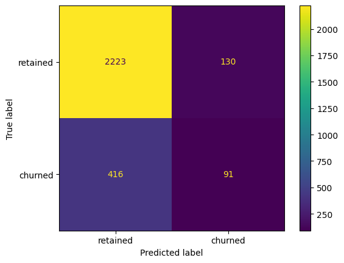

```python
# Generate array of values for confusion matrix

cm = confusion_matrix(y_test, xgb_test_preds, labels = xgb_cv.classes_)

# Plot confusion matrix

disp = ConfusionMatrixDisplay(confusion_matrix = cm, display_labels = ['retained', 'churned'])
disp.plot()

plt.show()
```

#### Comments

The model predicted three times as many false negatives than it did false positives.

#### 5.7 Feature importance

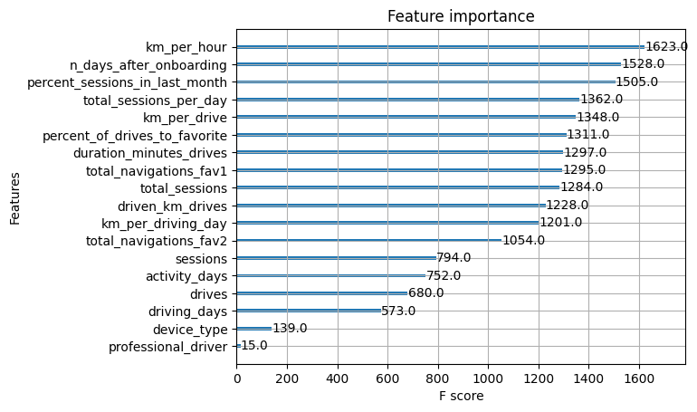

```python
# Inspect the most important features of the final model

plot_importance(xgb_cv.best_estimator_)

plt.show()
```

#### Comments

This underscores the importance of feature engineering because engineered features accounted for many of the top features.